# project 2 exec summary

2025-11-07

This project examines play-level performance data from the NFL using nflfastR data (2015–2025) to predict offensive yardage outcomes. The main goal is to design an efficient, reproducible workflow that accurately models play success while minimizing redundant preprocessing.

Unlike earlier reports, this analysis devotes most attention to model formulation, feature selection, and result interpretation—while presenting data preparation only as a supporting step. All filtering and eligibility checks are completed before modeling, ensuring a clean logical flow and reduced runtime.

1. Project Objective

The primary objective is to build a regression model capable of predicting yards gained on an offensive play based on situational and contextual factors (e.g., down, distance, field position, game quarter, formation indicators). The model should identify patterns that contribute to play success while being interperetable as to why it made certain decisions. Overall it helps quantify offensive tendencies and assess situation based decision-making efficiency.

2. Data Overview

The dataset comes from the publicly available nflfastR play-by-play repository, spanning regular-season games from 2015 through 2025 (we thought this was an accurate representation of this ‘era’ of football). Each row represents an individual play, including:

- Game identifiers and metadata (season, game ID, teams)
- Play context (down, yards to go, quarter, time remaining, play type)
- Formation indicators (e.g., shotgun, no-huddle)
- Positional and player-level IDs
- Yardline data before and after the play

The outcome variable (yards_manual) measures net yards gained on each offensive play. - This variable was made to account for plays where a penalty occurs (the traditional yards_gained column does not account for penalty yardage, which occurs on 7% of plays), to do this we took the difference between this play and the next plays yardline_100 to get the true yards gained.

```r
library(nflfastR)
library(dplyr)
library(xgboost)
library(caret)
pbp <- load_pbp(2015:2025)
```

3. Data Preparation

###Clean data to select only offensive (run/pass) plays. Filter to only include variables that we want.

```r
offense_plays <- pbp %>%
  filter(season_type == "REG",
         play_type %in% c("run", "pass"),
         !qb_spike,
         !qb_kneel) %>%
  group_by(game_id, drive) %>%
  arrange(game_id, drive, play_id) %>%
  mutate(
    next_yardline_100 = dplyr::lead(yardline_100),
    yards_manual = yardline_100 - next_yardline_100
  ) %>%
  ungroup() %>%
  filter(!is.na(yards_manual)) %>%
  select(
    season, game_id, posteam, defteam, down, ydstogo, yardline_100,
    qtr, half_seconds_remaining, score_differential, desc,
    play_type, run_location, pass_location, pass_length,
    shotgun, no_huddle, qb_scramble, goal_to_go,
    yards_manual
  )

cat("Total plays loaded:", nrow(pbp), "\n")
```

```
## Total plays loaded: 506921
```

```r
cat("Seasons:", unique(pbp$season), "\n")
```

```
## Seasons: 2015 2016 2017 2018 2019 2020 2021 2022 2023 2024 2025
```

```r
cat("Play types:", table(pbp$play_type), "\n")
```

```
## Play types: 13395 11172 29435 48162 211816 24008 4501 751 148804
```

```r
cat("Offensive plays retained:", nrow(offense_plays), "\n")
```

```
## Offensive plays retained: 286096
```

```r
cat("Percentage of original data:", round(100 * nrow(offense_plays)/nrow(pbp), 1), "%\n")
```

```
## Percentage of original data: 56.4 %
```

###Features include both situational and contextual factors: Down, yards to go, yardline position, quarter, and time remaining

```r
df <- offense_plays %>%
  mutate(
    play_type = factor(play_type),
    pass_length = factor(pass_length, levels = c("short","deep")),
    run_location = factor(run_location),
    qtr = factor(qtr),
    shotgun = as.integer(shotgun),
    no_huddle = as.integer(no_huddle),
    qb_scramble = as.integer(qb_scramble),
    goal_to_go = as.integer(goal_to_go)
  ) %>%
  filter(!is.na(down), !is.na(ydstogo), !is.na(yardline_100),
         !is.na(qtr), !is.na(score_differential), !is.na(yards_manual))
```

###Reproducibility and Efficiency

The entire preprocessing step is designed to scale efficiently:

###Training and Validation Strategy We used an XGBoost model with an 80% training, 20% test split.

```r
train_idx <- caret::createDataPartition(df$yards_manual, p = 0.8, list = FALSE)
train <- df[train_idx, ]
test  <- df[-train_idx, ]

# Fit logistic model for pass/run tendency
pass_glm <- glm(I(play_type == "pass") ~ down + ydstogo + yardline_100 + qtr +
                  half_seconds_remaining + score_differential,
                data = train, family = binomial())

# Features formula for XGBoost
formula_feats <- ~ down + ydstogo + yardline_100 + qtr +
  half_seconds_remaining + score_differential +
  play_type + goal_to_go

X_train <- model.matrix(formula_feats, data = train)[, -1]
X_test  <- model.matrix(formula_feats, data = test)[, -1]

y_train <- train$yards_manual
y_test  <- test$yards_manual

dtrain <- xgb.DMatrix(data = X_train, label = y_train)
dtest  <- xgb.DMatrix(data = X_test, label = y_test)

params <- list(
  objective = "reg:squarederror",
  eta = 0.1,
  max_depth = 6,
  subsample = 0.7,
  colsample_bytree = 0.7
)

xgb_model <- xgb.train(params = params,
                       data = dtrain,
                       nrounds = 200,
                       watchlist = list(train = dtrain),
                       verbose = 0)
```

```r
pred_test <- predict(xgb_model, dtest)
rmse_test <- sqrt(mean((pred_test - y_test)^2))

cat("\n=== MODEL PERFORMANCE ===\n")
```

```
##
## === MODEL PERFORMANCE ===
```

```r
cat("Test RMSE:", round(rmse_test, 3), "yards\n")
```

```
## Test RMSE: 8.27 yards
```

```r
cat("Test MAE:", round(mean(abs(pred_test - y_test)), 3), "yards\n")
```

```
## Test MAE: 5.612 yards
```

```r
cat("Test R²:", round(cor(pred_test, y_test)^2, 3), "\n")
```

```
## Test R²: 0.103
```

```r
importance_matrix <- xgb.importance(model = xgb_model)
print(importance_matrix[1:10,])
```

```
##                    Feature        Gain       Cover   Frequency
##                     <char>       <num>       <num>       <num>
##  1:           yardline_100 0.265480637 0.179859322 0.216824433
##  2:                   down 0.229269768 0.069929654 0.068762279
##  3:           play_typerun 0.149425343 0.042077183 0.032773710
##  4:                ydstogo 0.134199920 0.126386023 0.149044472
##  5: half_seconds_remaining 0.104572768 0.313126667 0.254420432
##  6:     score_differential 0.074100103 0.220806644 0.201196642
##  7:             goal_to_go 0.017316100 0.010469640 0.007947848
##  8:                   qtr4 0.012445277 0.011493645 0.021968209
##  9:                   qtr2 0.007239821 0.007824377 0.020717985
## 10:                   qtr3 0.003959831 0.008922207 0.018842650
```

```r
cat("\nPredicted yards - Summary:\n")
```

```
##
## Predicted yards - Summary:
```

```r
print(summary(pred_test))
```

```
##    Min. 1st Qu.  Median    Mean 3rd Qu.    Max.
##  -5.515   4.379   5.363   5.905   7.122  28.496
```

```r
cat("\nActual yards - Summary:\n")
```

```
##
## Actual yards - Summary:
```

```r
print(summary(y_test))
```

```
##    Min. 1st Qu.  Median    Mean 3rd Qu.    Max.
## -98.000   0.000   4.000   5.894   9.000  81.000
```

The feature importance results from the gradient-boosted regression model provide valuable insight into which variables most strongly influence play-level yardage predictions. Each metric in the table—Gain, Cover, and Frequency—captures a different aspect of importance. Gain measures how much a feature improves model accuracy when it is used in a split, Cover represents the proportion of plays affected by those splits, and Frequency indicates how often the feature appears across all trees in the model. Together, they show both the magnitude and consistency of each variable’s contribution.

The analysis reveals that field position (yardline_100) is the most influential predictor in the model. This makes sense because plays that occur closer to the opponent’s end zone naturally have less room to gain yardage.

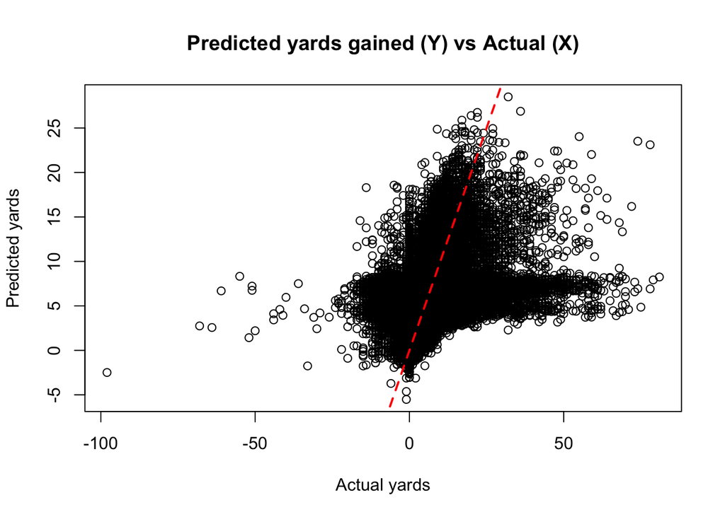

```r
plot(y_test, pred_test, main = 'Predicted yards gained (Y) vs Actual (X)', xlab = 'Actual yards', ylab = 'Predicted yards')
abline(0, 1, col = "red", lwd = 2, lty = 2)
```

###Feature Selection

6. Model Interpretation

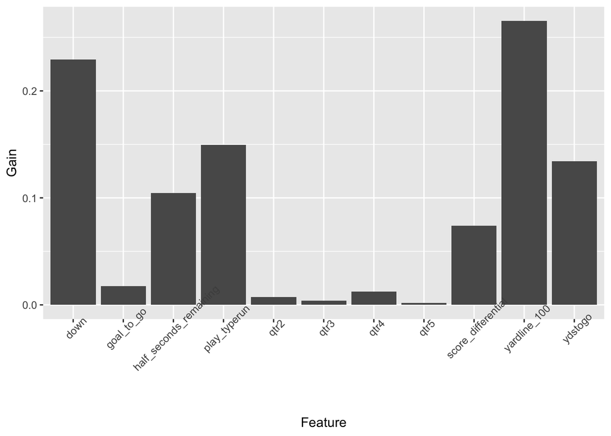

```r
importance_matrix %>% ggplot(aes(x = Feature, y = Gain)) + geom_col() + theme(axis.text.x = element_text(angle = 45))
```

###Now onto predicting and making decisions###

Helper function to predict yards. Its primary role is to translate a single game state (represented as one row of situational variables) into a model-compatible feature vector and generate a predicted yardage outcome using our XGBoost model.

It builds a model matrix from the input row, checks for any missing features compared to the training data, fills them with zeros, and reorders columns to match the model’s structure. This ensures consistent input formatting before passing it to the trained XGBoost model for prediction.

```r
predict_yards <- function(state_row) {
  mm <- model.matrix(formula_feats, data = state_row)[, -1, drop = FALSE]
  missing_cols <- setdiff(colnames(X_train), colnames(mm))
  if(length(missing_cols) > 0) {
    add_mat <- matrix(0, nrow = nrow(mm), ncol = length(missing_cols))
    colnames(add_mat) <- missing_cols
    mm <- cbind(mm, add_mat)
  }
  mm <- mm[, colnames(X_train), drop = FALSE]
  pred <- predict(xgb_model, newdata = mm)
  return(as.numeric(pred))
}
```

The fg_model predicts field goal success as a function of kick distance, while the go4it_model predicts conversion success based on out factors.

The paired predict_fg_success() and predict_go4it_success() functions generate probabilities for new scenarios, enabling dynamic evaluation of each choice. Together, they form the probabilistic backbone of the decision model, translating raw game states into actionable ‘success’ odds.

```r
fg_model <- glm(fg_made ~ kick_distance, data = fg_data, family = binomial())

go4it_model <- glm(converted ~ ydstogo + yardline_100 + qtr + score_differential,
                   data = go4it_data, family = binomial())

predict_fg_success <- function(fg_distance) {
  newdata <- data.frame(kick_distance = fg_distance)
  predict(fg_model, newdata = newdata, type = "response")
}

predict_go4it_success <- function(yardline_100, ydstogo, qtr = 2, score_differential = 0) {
  newdata <- data.frame(
    ydstogo = ydstogo,
    yardline_100 = yardline_100,
    qtr = qtr,
    score_differential = score_differential
  )
  predict(go4it_model, newdata = newdata, type = "response")
}
```

Predicted field goal success for a 29 yd fieldgoal versus a 55 yarder:

```r
paste("29 Yarder: ", predict_fg_success(29))
```

```
## [1] "29 Yarder:  0.965259959781275"
```

```r
paste("55 Yarder: ", predict_fg_success(55))
```

```
## [1] "55 Yarder:  0.612342044843508"
```

Because we need to weight the decision on the same scale (fg vs go for it) and going for it has a much higher reward (potential touchdown 7 points versus 3 for a FG), we need to put them both in terms of expected points in order to optimally weigh the decisions.

###This is how we do it###

get_ep_by_field_position: Maps yardline to expected points using historical averages, with linear interpolation for intermediate positions.

expected_points_go4it: Computes EP for a 4th-down attempt by weighting scenarios—successful conversion, partial gain, or total failure—using predicted conversion probability and expected yards. Adjusts for aggressive attempts and conservative coaching tendencies.

expected_points_fg: Computes EP for a field goal attempt, combining probability of success (from a kick-distance model) with EP consequences of a miss.

expected_points_punt: Computes EP for a punt, accounting for average punt distance, field position effects, touchbacks, and returns. Returns the negative EP of the opponent’s resulting field position, adjusted for coaching conservatism.

Purpose: These functions allow analysts to quantitatively compare strategic options on each play, translating complex game states into expected point outcomes to guide optimal decision-making.

```r
# Create a proper Expected Points table based on field position
# This is based on historical NFL data
get_ep_by_field_position <- function(yardline_100) {
  # yardline_100 is yards from opponent's endzone
  # These values are approximations from NFL analytics
  ep_table <- data.frame(
    yardline = c(99, 95, 90, 85, 80, 75, 70, 65, 60, 55, 50, 45, 40, 35, 30, 25, 20, 15, 10, 5, 1),
    ep = c(-1.25, -0.75, -0.50, 0.00, 0.40, 0.70, 1.00, 1.30, 1.55, 1.75, 2.00, 2.20, 2.40, 2.65, 2.90, 3.25, 3.65, 4.10, 4.60, 5.50, 6.00)
  )

  # Linear interpolation for yardlines not in the table
  approx(ep_table$yardline, ep_table$ep, xout = yardline_100, rule = 2)$y
}

# Updated EPA calculation for going for it with conversion odds and expected yards
expected_points_go4it <- function(yardline_100, ydstogo, qtr = 2, score_differential = 0) {
  # Probability of converting (gaining enough yards for first down)
  p_convert <- predict_go4it_success(yardline_100, ydstogo, qtr, score_differential)

  # Create a state for predicting yards on 4th down attempt
  state_row <- data.frame(
    down = 4,
    ydstogo = ydstogo,
    yardline_100 = yardline_100,
    qtr = factor(qtr, levels = levels(train$qtr)),
    half_seconds_remaining = 900,  # neutral
    score_differential = score_differential,
    play_type = factor("pass", levels = c("run", "pass")),  # assume pass on 4th
    goal_to_go = as.integer(yardline_100 <= 10)
  )

  # Predict expected yards gained on the attempt
  expected_yards <- predict_yards(state_row)

  # Scenario 1: Conversion (gain >= ydstogo)
  # New field position after converting
  new_yardline_convert <- max(1, yardline_100 - ydstogo)
  ep_convert <- get_ep_by_field_position(new_yardline_convert)

  # Scenario 2: Partial gain but no conversion (0 < gain < ydstogo)
  # Opponent gets ball where we ended up
  yards_gained_fail <- max(0, min(expected_yards, ydstogo - 0.5))  # likely partial yards
  fail_yardline <- yardline_100 - yards_gained_fail
  opp_yardline_partial <- 100 - fail_yardline
  ep_partial_fail <- -get_ep_by_field_position(opp_yardline_partial)

  # Scenario 3: Complete failure (negative or zero yards, sack, etc.)
  # Opponent gets ball at original spot
  opp_yardline_no_gain <- 100 - yardline_100
  ep_total_fail <- -get_ep_by_field_position(opp_yardline_no_gain)

  # Weight the scenarios
  # If we convert: use conversion probability
  # If we don't convert: split between partial gain and total failure
  p_partial_fail <- (1 - p_convert) * 0.7  # 70% of failures are partial gains
  p_total_fail <- (1 - p_convert) * 0.3     # 30% of failures are no gain/negative

  # Calculate weighted EPA
  ep_go4it <- (p_convert * ep_convert) +
    (p_partial_fail * ep_partial_fail) +
    (p_total_fail * ep_total_fail)

  # Penalize aggressive 4th down attempts based on yards to go
  penalty <- if (ydstogo > 5) {
    # scale penalty linearly beyond 5 yards, up to -3.0 EPA
    min(0.5 * (ydstogo - 5))
  } else {
    0
  }

  #add a weighting to simulate conservative coaching
  return(ep_go4it - penalty - 1.5)
}

expected_points_fg <- function(yardline_100) {
  fg_dist <- 117 - (100 - yardline_100)
  if (fg_dist > 70) {
    return(-Inf) # Disallow long FG
  }
  p_fg <- predict_fg_success(fg_dist)
  ep_make <- 3  # Made FG

  # If miss: opponent gets ball at spot of kick (roughly)
  # Missed FGs from <30 yards: ball at spot of kick
  # Missed FGs from 30+ yards: ball at original line of scrimmage
  if (fg_dist < 38) {
    # Short miss - they get it at the spot
    miss_yardline <- min(80, 100 - yardline_100)
  } else {
    # Long miss - they get it at line of scrimmage
    miss_yardline <- 100 - yardline_100
  }
  ep_miss <- -get_ep_by_field_position(miss_yardline)

  return(p_fg * ep_make + (1 - p_fg) * ep_miss)
}

# Updated punt EPA with more realistic punt modeling
expected_points_punt <- function(yardline_100) {
    #if comfortably in fg range do not consider punting
  if (yardline_100 <= 38) {
    return(-Inf) # Disallow long FG
  }
  # Use average punt distance
  avg_punt <- mean(punt_data$punt_distance, na.rm = TRUE)

  # Adjust punt distance based on field position
  # Punts from deep in your territory go farther
  # Punts near opponent endzone are shorter (coffin corner attempts)
  if (yardline_100 > 60) {
    # Deep in own territory - longer punts
    punt_distance <- avg_punt * 1.1
  } else if (yardline_100 < 35) {
    # Near opponent endzone - shorter, more careful punts
    punt_distance <- avg_punt * 0.7
  } else {
    punt_distance <- avg_punt
  }

  # Calculate where opponent gets the ball
  gross_yardline <- yardline_100 + punt_distance

  # Account for touchbacks (ball placed at 20)
  if (gross_yardline >= 100) {
    opp_yardline <- 20
  } else {
    # Account for punt returns (average ~8 yards)
    avg_return <- 8
    net_punt <- punt_distance - avg_return
    opp_yardline <- max(100 - (yardline_100 + net_punt), 5)  # minimum at their 5
  }

  # Our EP = negative of opponent's EP, add a weighting to simulate conservative coaching
  return(-get_ep_by_field_position(opp_yardline) + 2.5)
}
```

Finally, we have a all encomapssing model to weigh the options by ep. This is the culmination of all of it:

```r
#Now our function to make the decision based on ep.
should_go_for_it <- function(yardline_100, ydstogo) {
  ep_go4it <- expected_points_go4it(yardline_100, ydstogo)
  ep_fg    <- expected_points_fg(yardline_100)
  ep_punt  <- expected_points_punt(yardline_100)

  decisions <- c("GO FOR IT", "FIELD GOAL", "PUNT")
  best <- which.max(c(ep_go4it, ep_fg, ep_punt))

  cat(sprintf("\n4th Down Decision (%d yards to go, %.0f yards from endzone): %s\n",
              ydstogo, yardline_100, decisions[best]))
  cat(sprintf("Expected Points → Go: %.2f | FG: %.2f | Punt: %.2f\n",
              ep_go4it, ep_fg, ep_punt))

  list(
    decision = decisions[best],
    ep_go = ep_go4it,
    ep_fg = ep_fg,
    ep_punt = ep_punt
  )
}
```

```r
should_go_for_it(60, 1)
```

```
##
## 4th Down Decision (1 yards to go, 60 yards from endzone): PUNT
## Expected Points → Go: 0.08 | FG: -Inf | Punt: 0.42
```

```
## $decision
## [1] "PUNT"
##
## $ep_go
##          1
## 0.07981141
##
## $ep_fg
## [1] -Inf
##
## $ep_punt
## [1] 0.42
```

Now we make an equation to handle rmse and adding noise for the inherent unpredictability of a football play.

```r
model_rmse <- rmse_test
add_noise <- function(pred, rmse = model_rmse) {
  as.numeric(rnorm(1, mean = pred, sd = rmse))
}
```

Get rates of turnovers and sacks

```r
fumble_rate <- mean(pbp$fumble == 1, na.rm = TRUE)
interception_rate <- mean(pbp$interception == 1, na.rm = TRUE)
sack_rate <- mean(pbp$sack == 1, na.rm = TRUE)
```

Now we have all the aspects ready to simulate one play: It makes a decision based on probabilities (pass/run choice via simple logistic regression based on all of the data), yardage prediction (XGBoost model), and stochastic events (turnovers, sacks, TDs) to update the game ‘state.’ The function outputs both the new state (down, distance, yardline, time, score context) and the play result (yards gained, type, touchdowns, turnovers, sacks), which will lead to iterative simulation of drives or full games.

```r
simulate_play <- function(state, use_noise = TRUE, verbose = FALSE) {
  if(!is.null(state$force_play_type)) {
    chosen_play <- state$force_play_type
    # Decide whether to pass or run based on logistic regression model
  } else {
    pg_df <- data.frame(
      down = as.numeric(state$down),
      ydstogo = as.numeric(state$ydstogo),
      yardline_100 = as.numeric(state$yardline_100),
      qtr = factor(state$qtr, levels = levels(train$qtr)),
      half_seconds_remaining = as.numeric(state$half_seconds_remaining),
      score_differential = as.numeric(state$score_differential)
    )
    pass_prob <- predict(pass_glm, newdata = pg_df, type = "response")
    chosen_play <- ifelse(runif(1) < pass_prob, "pass", "run")
  }

  # Predict yards gained using XGBoost model
  state_row <- data.frame(
    down = as.numeric(state$down),
    ydstogo = as.numeric(state$ydstogo),
    yardline_100 = as.numeric(state$yardline_100),
    qtr = factor(state$qtr, levels = levels(train$qtr)),
    half_seconds_remaining = as.numeric(state$half_seconds_remaining),
    score_differential = as.numeric(state$score_differential),
    play_type = factor(chosen_play, levels = c("run", "pass")),
    goal_to_go = as.integer(state$goal_to_go)
  )

  pred_y <- predict_yards(state_row)
  pred_with_noise <- if(use_noise) add_noise(pred_y) else pred_y
  yards_manual <- round(pred_with_noise, 0)

  # Random turnovers or sacks
  is_fumble <- runif(1) < fumble_rate
  is_interception <- (!is_fumble && chosen_play == "pass") && (runif(1) < interception_rate)
  is_sack <- (!is_fumble && !is_interception && chosen_play == "pass") && (runif(1) < sack_rate)

  #update yardline
  new_yardline <- max(0, state$yardline_100 - yards_manual)
  is_td <- (new_yardline == 0)

  #Update time
  time_used <- ifelse(chosen_play == "run", 40, 8)
  new_seconds <- max(0, state$half_seconds_remaining - time_used)

  # Update down/distance
  if (!is_td) {
    yards_to_marker <- state$ydstogo - yards_manual
    if (yards_manual >= state$ydstogo) {
      new_down <- 1
      new_ydstogo <- min(10, new_yardline)
    } else {
      new_down <- state$down + 1
      new_ydstogo <- ifelse(new_down <= 4, max(1, state$ydstogo - yards_manual), NA)
    }
  } else {
    new_down <- 1
    new_ydstogo <- 10
  }

  # --- NEW: Simulate turnovers and sacks ---
  turnover <- FALSE
  turnover_type <- NA
  sack <- FALSE

  # Probabilities (adjust as needed)
  prob_fumble <- (mean(pbp$fumble == 1, na.rm = TRUE) / 2)
  prob_interception <- mean(pbp$interception == 1, na.rm = TRUE)
  prob_sack <- mean(pbp$sack == 1, na.rm = TRUE)

  if(runif(1) < prob_fumble) {
    turnover <- TRUE
    turnover_type <- "FUMBLE"
  } else if(runif(1) < prob_interception) {
    turnover <- TRUE
    turnover_type <- "INTERCEPTION"
  } else if(runif(1) < prob_sack) {
    sack <- TRUE
    # sack: lose some yards
    sack_yards <- sample(2:10, 1)
    new_yardline <- min(100, new_yardline + sack_yards)
    # down/distance stays the same
  }

  # Build play result
  play_result <- list(
    yards_manual = yards_manual,
    play_type = chosen_play,
    is_td = is_td,
    event = if (is_td) "TOUCHDOWN" else if (turnover) turnover_type else if(sack) "SACK" else "PLAY",
    turnover = turnover,
    turnover_type = turnover_type,
    sack = sack
  )

  #build next state
  new_state <- list(
    down = new_down,
    ydstogo = new_ydstogo,
    yardline_100 = new_yardline,
    qtr = state$qtr,
    half_seconds_remaining = new_seconds,
    score_differential = state$score_differential,
    goal_to_go = as.integer(new_yardline <= 10)
  )

  if (verbose) {
    cat("Play:", chosen_play,
        "| Yds:", yards_manual,
        "| New yardline:", new_yardline,
        "| Down:", new_down, "ToGo:", new_ydstogo,
        "| Time left(s):", new_seconds,
        if(sack) "| SACK!",
        if(turnover) paste0("| ", turnover_type, "!"),
        "\n")
  }

  list(state = new_state, result = play_result)
}
```

Simple 1st and 10 at our own 25 (standard drive starter):

```r
simulate_play(state = list(
    down = 1,
    ydstogo = 10,
    yardline_100 = 75,
    qtr = 1,
    half_seconds_remaining = 1800,
    score_differential = 0,
    goal_to_go = as.integer(75 <= 10)
  ))
```

```
## $state
## $state$down
## [1] 1
##
## $state$ydstogo
## [1] 10
##
## $state$yardline_100
## [1] 58
##
## $state$qtr
## [1] 1
##
## $state$half_seconds_remaining
## [1] 1792
##
## $state$score_differential
## [1] 0
##
## $state$goal_to_go
## [1] 0
##
##
## $result
## $result$yards_manual
## [1] 17
##
## $result$play_type
##      1
## "pass"
##
## $result$is_td
## [1] FALSE
##
## $result$event
## [1] "PLAY"
##
## $result$turnover
## [1] FALSE
##
## $result$turnover_type
## [1] NA
##
## $result$sack
## [1] FALSE
```

Similar function to encapsulate the 4th down decision:

```r
simulate_fourth_down <- function(state, verbose = TRUE) {
  yardline_100 <- state$yardline_100
  ydstogo <- state$ydstogo

  ep_go4it <- expected_points_go4it(yardline_100, ydstogo)
  ep_fg    <- expected_points_fg(yardline_100)
  ep_punt  <- expected_points_punt(yardline_100)

  decisions <- c("GO FOR IT", "FIELD GOAL", "PUNT")
  best <- which.max(c(ep_go4it, ep_fg, ep_punt))
  best_decision <- decisions[best]

  if (verbose) {
    cat(sprintf("\n4th Down Decision — %.0f yards from endzone, %d yards to go:\n",
                yardline_100, ydstogo))
    cat(sprintf("  Go for it:  %.2f EP\n", ep_go4it))
    cat(sprintf("  Field goal: %.2f EP\n", ep_fg))
    cat(sprintf("  Punt:       %.2f EP\n", ep_punt))
    cat(sprintf("  → Optimal Decision: %s\n", best_decision))
  }

  return(list(
    decision = best_decision,
    ep_go = ep_go4it,
    ep_fg = ep_fg,
    ep_punt = ep_punt
  ))
}
```

Example simulate 4th down.

```r
# Example starting state
state <- list(
  down = 4,
  ydstogo = 3,
  yardline_100 = 45,  # 45 yards from end zone
  qtr = 2,
  half_seconds_remaining = 900,
  score_differential = 0,
  goal_to_go = 0
)

simulate_fourth_down(state)
```

```
##
## 4th Down Decision — 45 yards from endzone, 3 yards to go:
##   Go for it:  0.80 EP
##   Field goal: 0.25 EP
##   Punt:       1.10 EP
##   → Optimal Decision: PUNT
```

```
## $decision
## [1] "PUNT"
##
## $ep_go
##         1
## 0.8003677
##
## $ep_fg
##         1
## 0.2542229
##
## $ep_punt
## [1] 1.1
```

Now we have everything we need to simulate an entire drive, as we can keep getting less and less granular with all of the pieces. It integrates play simulations (simulate_play), fourth-down decision logic with EP calculations, and tracks scoring outcomes (TD, FG, punt) and drive-level stats, returning both the final state and a detailed play-by-play summary.

```r
simulate_drive <- function(
    start_state,
    use_noise = TRUE,
    verbose = TRUE,
    max_plays = 20
) {
  state <- start_state
  drive_summary <- list()
  play_count <- 0
  drive_score <- 0
  drive_outcome <- NA  # track final result

  while (TRUE) {
    play_count <- play_count + 1
    if (play_count > max_plays) {
      if (verbose) cat("Drive ended: maximum plays reached.\n")
      drive_outcome <- "MAX_PLAYS"
      break
    }

    # Check if it's 4th down
    if (state$down == 4) {
      fd_decision <- simulate_fourth_down(state, verbose = verbose)
      decision <- fd_decision$decision

      # ALWAYS print EPA for 4th down decisions
      cat(sprintf("\n=== 4TH DOWN at own %d-yard line (%d yards to go) ===\n",
                  100 - state$yardline_100, state$ydstogo))
      cat(sprintf("  EPA if GO FOR IT:   %.3f\n", fd_decision$ep_go))
      cat(sprintf("  EPA if FIELD GOAL:  %.3f\n", fd_decision$ep_fg))
      cat(sprintf("  EPA if PUNT:        %.3f\n", fd_decision$ep_punt))
      cat(sprintf("  → DECISION: %s\n", decision))

      if (decision == "GO FOR IT") {
        play_res <- simulate_play(state, use_noise = use_noise, verbose = verbose)
        state <- play_res$state
        drive_summary[[play_count]] <- list(
          play_type = "4th_DOWN_GO",
          yards = play_res$result$yards_manual,
          new_state = state,
          is_td = play_res$result$is_td
        )
        if (play_res$result$is_td) {
          drive_score <- 7
          drive_outcome <- "TOUCHDOWN"
          if (verbose) cat("Touchdown! Drive ends.\n")
          break
        }
        if (play_res$result$turnover) {
          drive_outcome <- play_res$result$turnover_type
          if (verbose) cat(play_res$result$turnover_type, "— Drive ends!\n")
          break  # Drive ends on fumble or interception
        }
        # Check for turnover on downs
        if (state$down == 5) {
          drive_outcome <- "TURNOVER_ON_DOWNS"
          if (verbose) cat("Turnover on downs! Drive ends.\n")
          break
        }
      } else if (decision == "FIELD GOAL") {
        # Calculate FG distance and success probability
        fg_dist <- 117 - (100 - state$yardline_100)
        p_fg <- predict_fg_success(fg_dist)
        fg_made <- runif(1) < p_fg

        if (fg_made) {
          drive_score <- 3
          drive_outcome <- "FIELD_GOAL_MADE"
          if (verbose) cat(sprintf("Field goal MADE from %d yards! Drive ends. +3 points.\n", fg_dist))
        } else {
          drive_score <- 0
          drive_outcome <- "FIELD_GOAL_MISSED"
          if (verbose) cat(sprintf("Field goal MISSED from %d yards! Drive ends.\n", fg_dist))
        }

        drive_summary[[play_count]] <- list(
          play_type = "FIELD_GOAL",
          yards = NA,
          new_state = state,
          is_td = FALSE,
          fg_made = fg_made,
          fg_distance = fg_dist
        )
        break
      } else if (decision == "PUNT") {
        drive_outcome <- "PUNT"
        if (verbose) cat("Punt. Drive ends.\n")
        drive_summary[[play_count]] <- list(
          play_type = "PUNT",
          yards = NA,
          new_state = state,
          is_td = FALSE
        )
        break
      }
    } else {
      # Simulate normal play for downs 1-3
      play_res <- simulate_play(state, use_noise = use_noise, verbose = verbose)
      state <- play_res$state
      drive_summary[[play_count]] <- list(
        play_type = play_res$result$play_type,
        yards = play_res$result$yards_manual,
        new_state = state,
        is_td = play_res$result$is_td
      )
      if (play_res$result$is_td) {
        drive_score <- 7
        drive_outcome <- "TOUCHDOWN"
        if (verbose) cat("Touchdown! Drive ends.\n")
        break
      }
      if (play_res$result$turnover) {
        drive_outcome <- play_res$result$turnover_type
        if (verbose) cat(play_res$result$turnover_type, "— Drive ends!\n")
        break  # Drive ends on fumble or interception
      }
    }

    # Stop if half ends
    if (state$half_seconds_remaining <= 0) {
      drive_outcome <- "END_OF_HALF"
      if (verbose) cat("End of half reached. Drive ends.\n")
      break
    }

    # Stop if drive reaches endzone
    if (state$yardline_100 == 0) {
      drive_outcome <- "TOUCHDOWN"
      drive_score <- 7
      if (verbose) cat("Endzone reached! Touchdown. Drive ends.\n")
      break
    }
  }

  return(list(
    final_state = state,
    score = drive_score,
    plays = drive_summary,
    total_plays = play_count,
    outcome = drive_outcome
  ))
}
```

```r
# Starting drive state
drive_start <- list(
  down = 1,
  ydstogo = 10,
  yardline_100 = 75,
  qtr = 2,
  half_seconds_remaining = 900,
  score_differential = 0,
  goal_to_go = 0
)

simulate_drive(drive_start, verbose = FALSE)
```

```
##
## === 4TH DOWN at own 89-yard line (7 yards to go) ===
##   EPA if GO FOR IT:   3.025
##   EPA if FIELD GOAL:  2.894
##   EPA if PUNT:        -Inf
##   → DECISION: GO FOR IT
```

```
## $final_state
## $final_state$down
## [1] 5
##
## $final_state$ydstogo
## [1] NA
##
## $final_state$yardline_100
## [1] 10
##
## $final_state$qtr
## [1] 2
##
## $final_state$half_seconds_remaining
## [1] 620
##
## $final_state$score_differential
## [1] 0
##
## $final_state$goal_to_go
## [1] 1
##
##
## $score
## [1] 0
##
## $plays
## $plays[[1]]
## $plays[[1]]$play_type
##     1
## "run"
##
## $plays[[1]]$yards
## [1] 15
##
## $plays[[1]]$new_state
## $plays[[1]]$new_state$down
## [1] 1
##
## $plays[[1]]$new_state$ydstogo
```

[output cut: 362 more lines]

```
##
## $plays[[11]]$new_state$goal_to_go
## [1] 1
##
##
## $plays[[11]]$is_td
## [1] FALSE
##
##
##
## $total_plays
## [1] 11
##
## $outcome
## [1] "TURNOVER_ON_DOWNS"
```

Now finally, we can simulate as many drives as we want using simulate_multiple_drives which repeatedly calls simulate_drive to generate large samples of simulated drives, aggregating outcomes for statistical analysis (average score, average plays per outcome, frequency of drive endings). Together, these functions enable quantitative evaluation of offensive strategies and situational decision-making over thousands of simulated drives.

```r
simulate_multiple_drives <- function(
    start_state,
    n_drives = 1000,
    use_noise = TRUE,
    verbose = FALSE
) {
  results <- data.frame(
    drive = integer(),
    score = numeric(),
    outcome = character(),
    total_plays = integer(),
    stringsAsFactors = FALSE
  )

  for (i in 1:n_drives) {
    if (verbose) cat("\n--- Simulating drive", i, "---\n")

    drive_res <- simulate_drive(start_state, use_noise = use_noise, verbose = verbose)

    # Use the outcome directly from drive_res
    outcome <- drive_res$outcome
    if (is.na(outcome)) outcome <- "OTHER"

    results <- rbind(results, data.frame(
      drive = i,
      score = drive_res$score,
      outcome = outcome,
      total_plays = drive_res$total_plays,
      stringsAsFactors = FALSE
    ))
  }

  # Aggregate summary
  summary <- results %>%
    group_by(outcome) %>%
    summarise(
      count = n(),
      avg_score = mean(score),
      avg_plays = mean(total_plays),
      .groups = 'drop'
    )

  return(list(
    all_results = results,
    summary = summary
  ))
}
```

Running this would take up a ton of space but it outputs the result of every drive, how many plays it took and printing every 4th down decision.

##Conclusion: Overall, we successfully developed a robust simulation framework to evaluate offensive drive outcomes and decision-making in NFL games. Using historical play-by-play data, we can estimate expected points, success probabilities for field goals and fourth-down attempts, and likely yards gained on each play. This allows us to quantify the impact of situational factors—such as down, distance, field position, and time remaining—on offensive efficiency and decision quality.

The simulation also highlights the effect of random events like turnovers, sacks, and partial gains, providing a realistic assessment of drive outcomes over many iterations. By simulating multiple drives from the same starting position, we can assess average scoring potential and the distribution of possible results for different strategic choices.

However, there are limitations. Certain assumptions—like play-type probabilities, EPA penalties for aggressive decisions, and weights applied to punts or failed attempts—are based on simplified models or historical averages rather than fully optimized statistical estimates. Additionally, variations in opponent strength and game context are not explicitly incorporated, which could influence drive outcomes. Future improvements could include opponent-adjusted EPA, more granular player-level contributions, and machine learning models trained on situational success rates.

Overall, this project provides a strong starting point for quantifying the expected outcomes of plays and drives, offering actionable insight into optimal decision-making and offensive strategy.